# Assignment 4

Clayton Glenn

April 15, 2018

```r
getwd()
```

```
## [1] "C:/Users/cglen/Desktop/Stat Methods/Assignments/ASS4"
```

10/10 Completed

# 1 Question 1

## 1.1 A

```r
birds.df <- read.csv("NZBIRDS.csv", header = TRUE)
x <- birds.df[sample(nrow(birds.df),35, replace = FALSE, prob = NULL),]
head(x)
```

```
##       Species               Name Extinct Habitat Nest.Site Nest.Density
## 52 Shorebirds      H. ostralegus      No       A         G            H
## 78       Owls N. novaeseelandiae      No      TA         C            L
## 85  Songbirds          T. lyalli     Yes      TG         G            L
## 70    Parrots    N. meridionalis      No      TA         C            L
## 55 Shorebirds        C. obscurus      No       A         G            L
## 38  Waterfowl         C. atratus     Yes       A         G            L
##    Diet Flight Body.Mass Egg.Length
## 52    I    Yes       550         56
## 78    I    Yes       175         38
## 85    I     No        22         21
## 70    H    Yes       425         42
## 55    I    Yes       145         46
## 38    H    Yes      5000        104
```

## 1.2 B

$$Mean=\bar Y=\sum^n_{i=1}\frac{y_i}{n}$$
$$Standard\ Deviation=s=\sqrt{\frac{\sum^n_{i=1}(y_i-\bar Y)^2}{n-1}}$$
$$Confidence\ Interval\ of\ Y=\bar Y\ ^+_- t_{a/2}\frac{s_y}{\sqrt{n_y}}$$

```r
mean(x$Body.Mass)
```

```
## [1] 9830.143
```

```r
sd(x$Body.Mass)
```

```
## [1] 30025.8
```

```r
ci=c()
t=abs(qt(0.05/2,34))
ci[1]=mean(x$Body.Mass)-t*sd(x$Body.Mass)/sqrt(35)
ci[2]=mean(x$Body.Mass)+t*sd(x$Body.Mass)/sqrt(35)
ci
```

```
## [1]  -484.0796 20144.3653
```

## 1.3 C

We are 95% confident that the mean of the population lies within this interval based off the random sample taken from the data.

## 1.4 D

$$Mean=\mu=\sum^n_{i=1}\frac{x_i}{n}$$

```r
mean(birds.df$Body.Mass)
```

```
## [1] 9113.043
```

We now know that the actual population mean lies within our interval that we were 95% confident in.

## 1.5 E

```r
mean(x$Egg.Length,na.rm=TRUE)
```

```
## [1] 63.17647
```

```r
sd(x$Egg.Length,na.rm=TRUE)
```

```
## [1] 47.41594
```

```r
ci[1]=mean(x$Egg.Length,na.rm=TRUE)-t*sd(x$Egg.Length,na.rm=TRUE)/sqrt(35)
ci[2]=mean(x$Egg.Length,na.rm=TRUE)+t*sd(x$Egg.Length,na.rm=TRUE)/sqrt(35)
ci
```

```
## [1] 46.88853 79.46441
```

```r
mean(birds.df$Egg.Length,na.rm=TRUE)
```

```
## [1] 61.05652
```

As we can see from the confidence inteval, we can tell that the mean egg length of the population lies within the sample’s confidence interval.

$$CI\ of\ \hat P_e-\hat P_n=(\hat p_e-\hat p_n)\^+_-z_{a/2}\sqrt{\frac{s^2_e}{n_e}+\frac{s^2_n}{n_n}}$$
$$\hat P_e=\frac{Y}{n}=\frac{21}{38}=0.5526$$
$$\hat P_n=\frac{Y}{n}=\frac{7}{78}=0.0897$$
$$S=npq$$

```r
z = abs(qnorm((1-.95)/2))
ci[1]=(0.5526-0.0897)-z*sqrt(0.5*0.5+0.5*0.5)
ci[2]=(0.5526-0.0897)+z*sqrt(0.5*0.5+0.5*0.5)
ci
```

```
## [1] -0.9230038  1.8488038
```

# 2 Question 2

```r
z = abs(qnorm((1-.90)/2))
ci[1]=(1312-1352)-z*sqrt((422^2)/100+(271^2)/47)
ci[2]=(1312-1352)+z*sqrt((422)^2/100+(271)^2/47)
ci
```

```
## [1] -135.10916   55.10916
```

```r
f = qf((1-0.95), 46,99)
ci[2]=422^2/(271^2*f)
ci[1]=422^2*(f/271^2)
ci
```

```
## [1] 1.566267 3.754108
```

# 3 Question 3

$$Z=\frac{Y-\mu}{\sigma}=\frac{Y-0}{\sigma}=\frac{Y}{\sigma}$$
Multiply both sides by Z
$$Z^2=\frac{YZ}{\sigma}=\frac{YY}{\sigma\sigma}=\frac{Y^2}{\sigma^2}$$
With 1 degree freedom
$$P(X^2_{1-\alpha/2}\leq\frac{Y^2}{\sigma^2}\leq X^2_{\alpha/2})=1-\alpha$$
$$P(\frac{X^2_{1-\alpha/2}}{Y^2}\leq \frac{1}{\sigma^2}\leq \frac{X^2_{\alpha/2}}{Y^2})=1-\alpha$$
$$P(\frac{Y^2}{X^2_{1-\alpha/2}}\geq \sigma^2 \geq\frac{Y^2}{X^2_{\alpha/2}})=1-\alpha$$

# 4 Question 4

## 4.1 A

```r
x <- c(1.72,2.5,2.16,2.13,1.06,2.24,2.31,2.03,1.09,1.4,2.57,2.64,1.26,2.05,1.19,2.13,1.27,1.51,2.41,1.95)
t.test(x,mu=2)
```

```
##
##  One Sample t-test
##
## data:  x
## t = -1.0158, df = 19, p-value = 0.3225
## alternative hypothesis: true mean is not equal to 2
## 95 percent confidence interval:
##  1.635802 2.126198
## sample estimates:
## mean of x
##     1.881
```

The P-value of the t test is much greater than 0.05. Should not reject null hypothesis.

## 4.2 B

Test statistic is -1.02 and P-Value is 0.322.

## 4.3 C

The P-value of the t test is much greater than 0.05. Should not reject null hypothesis.

## 4.4 D

T.Test allows for testing over confidence intervals just like calculations of intervals.

# 5 Question 5

```r
x <- c(9.6,4.5,13.2,4.1,22.6,2.7,14.7,3.5,13.6,19.8,14.3,56.9,25.1,18.4,2.7,4.2,30.2,10.3,17.6,2.4,17.3,38.8,3.0,5.8,7.6)
sd(x)
```

```
## [1] 12.96369
```

```r
t.test(x,mu=15,conf.level = .1)
```

```
##
##  One Sample t-test
##
## data:  x
## t = -0.18668, df = 24, p-value = 0.8535
## alternative hypothesis: true mean is not equal to 15
## 10 percent confidence interval:
##  14.18673 14.84527
## sample estimates:
## mean of x
##    14.516
```

## 5.1 B

$$t=\frac{\bar y - \mu_0}{s/\sqrt{n}}\Rightarrow t(s/\sqrt{n})=\bar y - \mu_0\Rightarrow \bar y=\mu_0\ ^+_-t(s/\sqrt{n})$$
$$\bar y=15 -1.711(12.96/\sqrt{25})=10.565$$
$$\bar y=15 +1.711(12.96/\sqrt{25})=19.435$$
$$P(t<\frac{10.565-14}{2.592})+P(t>\frac{19.435-14}{2.592})=P(t<-1.33)+P(t>2.1)=.0980+.0232=0.1212$$
The likelyhood that the test will detect the mean is 14 g/m3 is 12.12%

# 6 Question 6

$$S^2_P=\frac{(n_1-1)S^2_1+(n_2-1)S^2_2}{n_1+n_2-2}=\frac{7(.1186^2)+3(.1865^2)}{10}=0.02028$$
$$t=\frac{(\bar y_1-\bar y_2)}{\sqrt{S^2_P(1/n_1+1/n_2)}}=\frac{.2738-.4521}{.02028(3/8)}=-2.045$$

# 7 Question 7

## 7.1 A

```r
sam1=rnorm(21,mean=9764,sd=639)
sam2=rnorm(7,mean=12312,sd=2652)
sam3=rnorm(39,mean=11544,sd=1279)
var.test(sam2,sam3,var=1,conf.level = 1-.05/2)
```

```
##
##  F test to compare two variances
##
## data:  sam2 and sam3
## F = 12.341, num df = 6, denom df = 38, p-value = 2.308e-07
## alternative hypothesis: true ratio of variances is not equal to 1
## 97.5 percent confidence interval:
##   3.877494 81.151223
## sample estimates:
## ratio of variances
##           12.34054
```

```r
qf(c(.05/2,1-.05/2),6,38)
```

```
## [1] 0.1991693 2.7633350
```

```r
2.763
```

```
## [1] 2.763
```

## 7.2 B

```r
var.test(sam1,sam2,var=1,conf.level = 1-.05/2)
```

```
##
##  F test to compare two variances
##
## data:  sam1 and sam2
## F = 0.026701, num df = 20, denom df = 6, p-value = 1.504e-09
## alternative hypothesis: true ratio of variances is not equal to 1
## 97.5 percent confidence interval:
##  0.003932287 0.098403405
## sample estimates:
## ratio of variances
##         0.02670081
```

```r
qf(c(.05/2,1-.05/2),6,20)
```

```
## [1] 0.1934834 3.1283400
```

```r
3.13
```

```
## [1] 3.13
```

# 8 Question 8

```r
gobi.df<-read.csv("GOBIANTS.csv",header=TRUE,sep = ",")

dry.df = within(gobi.df, {
  reg <- ifelse(Region == "Gobi Desert", "GS","DS")
  reg<-factor(reg)
})

des.df = subset(gobi.df,subset=Region=="Gobi Desert")
var.test(x=dry.df[dry.df$reg == "DS",]$AntSpecies,y=des.df$AntSpecies,conf.level = 0.95)
```

```
##
##  F test to compare two variances
##
## data:  dry.df[dry.df$reg == "DS", ]$AntSpecies and des.df$AntSpecies
## F = 1.3684, num df = 4, denom df = 5, p-value = 0.7264
## alternative hypothesis: true ratio of variances is not equal to 1
## 95 percent confidence interval:
##   0.1852264 12.8146380
## sample estimates:
## ratio of variances
##           1.368432
```

## 8.1 A

$$H_0=1,\ H_a\neq1$$

## 8.2 B

The test statistic is 1.3684

## 8.3 C

The rejection region is (0.1852,12.8146)

## 8.4 D

The P-Value of the test is 0.7264

## 8.6 F

To accept equal variances with this small of a sample, the P-Value must be under 0.05 and the ratio needs to equal 1.

# 9 Question 9

$$t=\frac{\bar d-d_0}{S_d/\sqrt{n}}=\frac{-32.6-0}{35/\sqrt{8}}=-2.63$$
With degree freedom = 7,
$$-2.365\leq T-value\leq2.365$$

# 10 Question 10

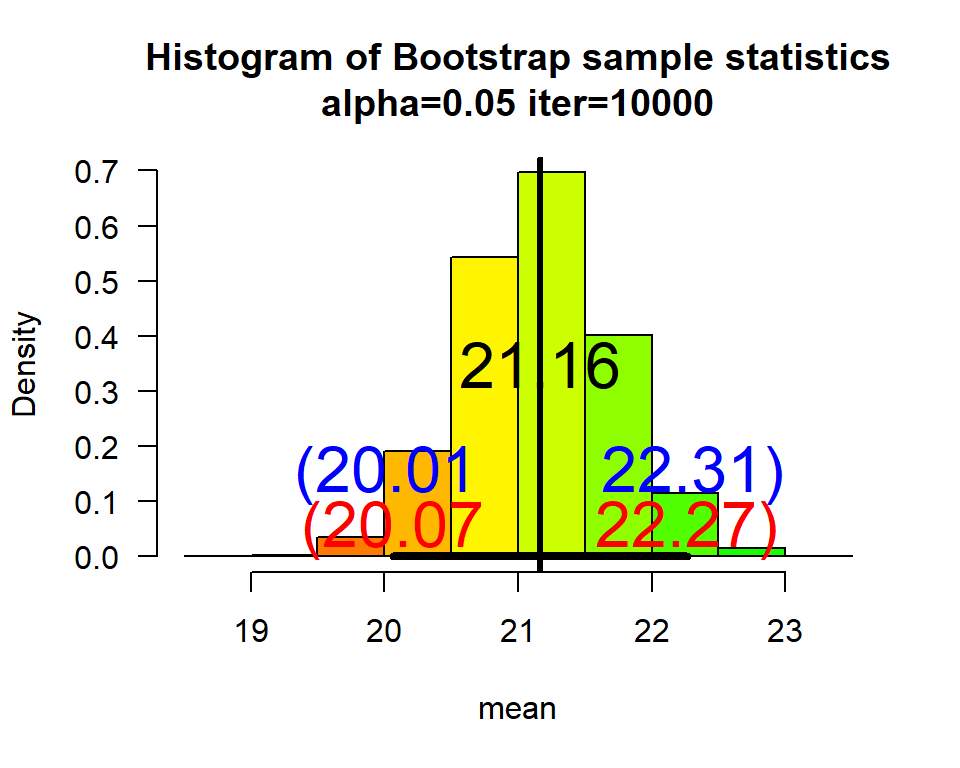

```
## $fun
## [1] "mean"
##
## $x
##  [1] 23.195 20.399 19.898 19.865 30.014 18.821 21.232 18.313 23.574 21.047
## [11] 21.535 21.336 17.695 18.497 14.274 14.664 22.593 18.963 25.515 25.019
## [21] 22.053 22.871 23.006 23.829 19.038 21.735 21.461 21.659 21.703 21.049
##
## $t
## [1] 2.04523
##
## $ci
##     2.5%    97.5%
## 20.06700 22.26845
##
## $cit
## [1] 20.01155 22.31198
```

```r
myboot<-function(iter=10000,x,fun="mean",alpha=0.05,...){
  n=length(x)
  y=sample(x,n*iter,replace=TRUE)
  rs.mat=matrix(y,nr=n,nc=iter,byrow=TRUE)
  xstat=apply(rs.mat,2,fun)
  ci=quantile(xstat,c(alpha/2,1-alpha/2))
  para=hist(xstat,freq=FALSE,las=1,
            main=paste("Histogram of Bootstrap sample statistics","\n","alpha=",alpha," iter=",iter,sep=""),
            ...)
  mat=matrix(x,nr=length(x),nc=1,byrow=TRUE)
  pte=apply(mat,2,fun)
  abline(v=pte,lwd=3,col="Black")
  segments(ci[1],0,ci[2],0,lwd=4)
  text(ci[1],0.05,paste("(",round(ci[1],2),sep=""),col="Red",cex=2)
  text(ci[2],0.05,paste(round(ci[2],2),")",sep=""),col="Red",cex=2)
  t=abs(qt(alpha/2,df=n-1))
  cit = c()
  cit[1]=mean(x)-t*sd(x)/sqrt(n)
  cit[2]=mean(x)+t*sd(x)/sqrt(n)
  text(cit[1],.15,paste("(",round(cit[1],2),sep=""),col="Blue",cex=2)
  text(cit[2],.15,paste(round(cit[2],2),")",sep=""),col="Blue",cex=2)
  text(pte,max(para$density)/2,round(pte,2),cex=2)
  return(list(fun=fun,x=x,t=t,ci=ci,cit=cit))
}
set.seed(35); sam<-round(rnorm(30,mean=20,sd=3),3)
myboot(10000,x=sam,alpha=0.05,xlab="mean",col=rainbow(length(x)))
```